# Diversificación de repertorios de participación

Anais Herrera-Leighton

```r
pacman::p_load(sjPlot, htmltools, sjlabelled,readr, summarytools, haven, dplyr,kableExtra,readxl, ggplot2,ggtext)
```

```r
# BBDD

#data <- haven::read_sav(file = url("https://github.com/part-ciu-juv/panel-jovenes/blob/main/input/data/original/Ola_1.sav?raw=true"))
data <- haven::read_sav("input/Ola_1.sav")
data = data %>%  filter(ci==1) %>% as.data.frame()
data_finished = data %>%  filter(Finished==1) %>% as.data.frame()

#sjPlot::view_df(data, show.frq =TRUE,show.prc =TRUE,file="codebook.html") # funciona sin encoding conectado a
```

```r
data2 <- haven::read_sav("input/Ola_2.sav")
data_finished2 = data2 %>%  filter(Finished==1) %>% as.data.frame()

#sjPlot::view_df(data2, show.frq =TRUE,show.prc =TRUE,file="codebook2.html") # funciona sin encoding
```

```r
data3 <- haven::read_sav("input/Ola_3.sav")
data_finished3 = data3 %>%  filter(Finished==1) %>% as.data.frame()

#sjPlot::view_df(data3, show.frq =TRUE,show.prc =TRUE,file="codebook_ola3.html") # funciona sin encoding
```

# Ola 1

## Participación política durante 3ro y 4to medio

**Durante el periodo en que cursaba 3° y 4° Medio, ¿realizó algunas de las siguientes actividades (dentro o fuera del liceo)?**

- Participar en marchas o protestas pacíficas (s2_p_e_05_4)
- Participar en marchas o protestas con disturbios (s2_p_e_05_5)
- Participar en bloqueo de calles o carreteras (s2_p_e_05_6)
- Pintar o rayar paredes con demandas o consignas (s2_p_e_05_7)
- Participar en la toma de un edificio o institución (s2_p_e_05_8)
- Trabajar como voluntario en servicios a la comunidad (s2_p_e_05_9)
- Firmar peticiones, presencialmente o por internet (s2_p_e_05_10)
- Participar en una marcha con mis amigos (s2_p_e_05_12)
- Participar en una marcha con alguno de mis padres (s2_p_e_05_14)
- Participar en una marcha con otros miembros de mi familia (s2_p_e_05_15)

**Durante el periodo en que cursaba 3° y 4° Medio, ¿con que frecuencia realizaba las siguientes actividades?**

- Usar internet para buscar información sobre temas sociales y/o políticos (s2_p_f_01_5)
- Postear imágenes o mensajes acerca de temas sociales y/o políticos en internet (s2_p_f_01_6)
- Compartir o comentar en el posteo de otra persona acerca de temas sociales y políticos (s2_p_f_01_7)
- Seguir a personas en redes sociales por su contenido sobre temas sociales y políticos (s2_p_f_01_8)

```r
### Recodificar variables
#se excluye + Participar en una marcha con compañeros del colegio (s2_p_e_05_13)

data$s2_p_e_05_4_rec = ifelse(data$s2_p_e_05_4==1|data$s2_p_e_05_4==2,0,1)
data$s2_p_e_05_5_rec = ifelse(data$s2_p_e_05_5==1|data$s2_p_e_05_5==2,0,1)
data$s2_p_e_05_6_rec = ifelse(data$s2_p_e_05_6==1|data$s2_p_e_05_6==2,0,1)
data$s2_p_e_05_7_rec = ifelse(data$s2_p_e_05_7==1|data$s2_p_e_05_7==2,0,1)
data$s2_p_e_05_8_rec = ifelse(data$s2_p_e_05_8==1|data$s2_p_e_05_8==2,0,1)
data$s2_p_e_05_9_rec = ifelse(data$s2_p_e_05_9==1|data$s2_p_e_05_9==2,0,1)
data$s2_p_e_05_10_rec = ifelse(data$s2_p_e_05_10==1|data$s2_p_e_05_10==2,0,1)
data$s2_p_e_05_12_rec = ifelse(data$s2_p_e_05_12==1|data$s2_p_e_05_12==2,0,1)
#data$s2_p_e_05_13_rec = ifelse(data$s2_p_e_05_13==1|data$s2_p_e_05_13==2,0,1)
data$s2_p_e_05_14_rec = ifelse(data$s2_p_e_05_14==1|data$s2_p_e_05_14==2,0,1)
data$s2_p_e_05_15_rec = ifelse(data$s2_p_e_05_15==1|data$s2_p_e_05_15==2,0,1)
data$s2_p_f_01_5_rec = ifelse(data$s2_p_f_01_5==1|data$s2_p_f_01_5==2,0,1)
data$s2_p_f_01_6_rec = ifelse(data$s2_p_f_01_6==1|data$s2_p_f_01_6==2,0,1)
data$s2_p_f_01_7_rec = ifelse(data$s2_p_f_01_7==1|data$s2_p_f_01_7==2,0,1)
data$s2_p_f_01_8_rec = ifelse(data$s2_p_f_01_8==1|data$s2_p_f_01_8==2,0,1)
```

```r
### Crear variable
data$part_pol_3y4 = as.numeric(data$s2_p_e_05_4_rec + data$s2_p_e_05_5_rec + data$s2_p_e_05_6_rec + data$s2_p_e_05_7_rec + data$s2_p_e_05_8_rec + data$s2_p_e_05_9_rec + data$s2_p_e_05_10_rec + data$s2_p_e_05_12_rec + data$s2_p_e_05_14_rec + data$s2_p_e_05_15_rec + data$s2_p_f_01_5_rec + data$s2_p_f_01_6_rec + data$s2_p_f_01_7_rec + data$s2_p_f_01_8_rec)
```

### Descriptivo 1: distribución de la variable

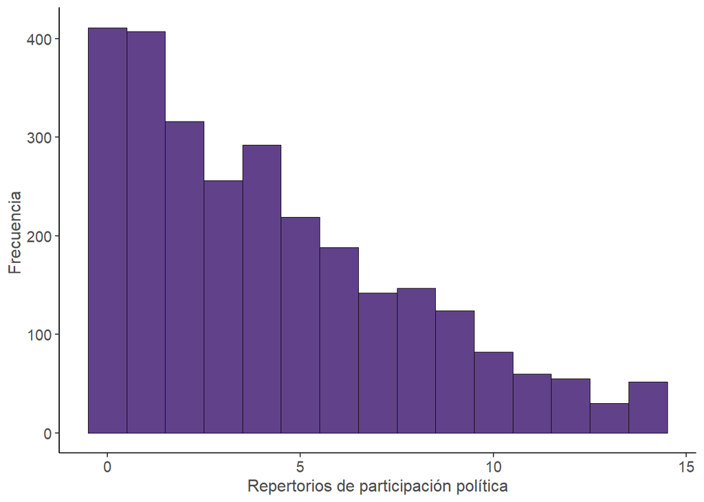

```r
pl <- ggplot(data, aes(x=part_pol_3y4))
dist<- pl + geom_histogram(binwidth=1, aes(fill=..count..), col='black', fill="#61418A") + theme("clasic") + set_theme(legend.pos  ="bottom", base = theme_classic()) + xlab("Repertorios de participación política") + ylab("Frecuencia ")
dist
```

### Descriptivo 2: frecuencias

```r
data$part_pol_3y4 %>% table()
```

```
## .
##   0   1   2   3   4   5   6   7   8   9  10  11  12  13  14
## 411 407 316 256 292 219 188 142 147 124  82  60  55  30  52
```

### Descriptivo 3: proporción

```r
round(prop.table(table(data$part_pol_3y4)),3)
```

```
##
##     0     1     2     3     4     5     6     7     8     9    10    11    12
## 0.148 0.146 0.114 0.092 0.105 0.079 0.068 0.051 0.053 0.045 0.029 0.022 0.020
##    13    14
## 0.011 0.019
```

### Descriptivo 4: estadísticos descriptivos

```r
summary(data$part_pol_3y4)
```

```
##    Min. 1st Qu.  Median    Mean 3rd Qu.    Max.    NA's
##   0.000   1.000   4.000   4.222   6.000  14.000     360
```

## Participación política durante estallido social

**Pensando en el periodo del estallido social, entre octubre de 2019 y enero de 2020, ¿realizó alguna de las siguientes actividades?**

- Firmar una petición, presencialmente o por internet (s3_es_01_1)
- Participar en una marcha o manifestación pacífica (s3_es_01_2)
- Participar en una marcha o manifestación con disturbios (s3_es_01_3)
- Participar en bloqueo de calles o carreteras (s3_es_01_7)
- Pintar o rayar paredes con demandas o consignas (s3_es_01_8)
- Participar en la toma de un edificio o institución (s3_es_01_9)
- Trabajar como voluntario en servicios a la comunidad (s3_es_01_10)
- Participar en una marcha con mis amigos (s3_es_01_11)
- Participar en una marcha con alguno de mis padres (s3_es_01_13)
- Participar en una marcha con otros miembros de mi familia (s3_es_01_14)

**Pensando en el periodo del estallido social, entre octubre de 2019 y enero de 2020, ¿con que frecuencia realizó las siguientes actividades?**

- Usar internet para buscar información sobre temas sociales y/o políticos (s3_es_02_5)
- Postear imágenes o mensajes acerca de temas sociales y/o políticos en internet (s3_es_02_6)
- Compartir o comentar en el posteo de otra persona acerca de temas sociales y políticos (s3_es_02_7)
- Seguir a personas en redes sociales por su contenido sobre temas sociales y políticos (s3_es_02_8)

```r
### Recodificar variables
# se excluye + Participar en una marcha con compañeros del colegio (s3_es_01_12)

data$s3_es_01_1_rec = ifelse(data$s3_es_01_1==1|data$s3_es_01_1==2,0,1)
data$s3_es_01_2_rec = ifelse(data$s3_es_01_2==1|data$s3_es_01_2==2,0,1)
data$s3_es_01_3_rec = ifelse(data$s3_es_01_3==1|data$s3_es_01_3==2,0,1)
data$s3_es_01_7_rec = ifelse(data$s3_es_01_7==1|data$s3_es_01_7==2,0,1)
data$s3_es_01_8_rec = ifelse(data$s3_es_01_8==1|data$s3_es_01_8==2,0,1)
data$s3_es_01_9_rec = ifelse(data$s3_es_01_9==1|data$s3_es_01_9==2,0,1)
data$s3_es_01_10_rec = ifelse(data$s3_es_01_10==1|data$s3_es_01_10==2,0,1)
data$s3_es_01_11_rec = ifelse(data$s3_es_01_11==1|data$s3_es_01_11==2,0,1)
#data$s3_es_01_12_rec = ifelse(data$s3_es_01_12==1|data$s3_es_01_12==2,0,1)
data$s3_es_01_13_rec = ifelse(data$s3_es_01_13==1|data$s3_es_01_13==2,0,1)
data$s3_es_01_14_rec = ifelse(data$s3_es_01_14==1|data$s3_es_01_14==2,0,1)
data$s3_es_02_5_rec = ifelse(data$s3_es_02_5==1|data$s3_es_02_5==2,0,1)
data$s3_es_02_6_rec = ifelse(data$s3_es_02_6==1|data$s3_es_02_6==2,0,1)
data$s3_es_02_7_rec = ifelse(data$s3_es_02_7==1|data$s3_es_02_7==2,0,1)
data$s3_es_02_8_rec = ifelse(data$s3_es_02_8==1|data$s3_es_02_8==2,0,1)
```

```r
### Crear variable
data$part_pol_es = as.numeric(data$s3_es_01_1_rec + data$s3_es_01_2_rec + data$s3_es_01_3_rec + data$s3_es_01_7_rec + data$s3_es_01_8_rec + data$s3_es_01_9_rec + data$s3_es_01_10_rec + data$s3_es_01_11_rec + data$s3_es_01_13_rec + data$s3_es_01_14_rec + data$s3_es_02_5_rec + data$s3_es_02_6_rec + data$s3_es_02_7_rec + data$s3_es_02_8_rec)
```

### Descriptivo 1: distribución de la variable

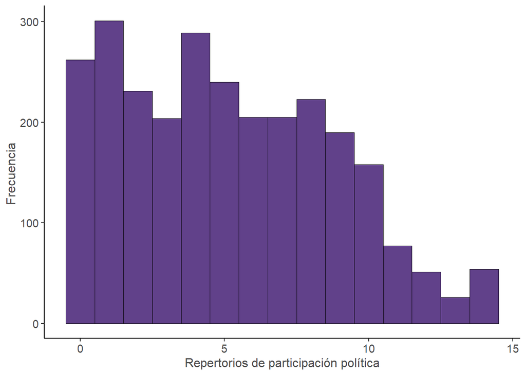

```r
pl <- ggplot(data, aes(x=part_pol_es))
dist<- pl + geom_histogram(binwidth=1, aes(fill=..count..), col='black', fill="#61418A") + theme("clasic") + set_theme(legend.pos  ="bottom", base = theme_classic()) + xlab("Repertorios de participación política") + ylab("Frecuencia ")
dist
```

### Descriptivo 2: frecuencias

```r
data$part_pol_es %>% table()
```

```
## .
##   0   1   2   3   4   5   6   7   8   9  10  11  12  13  14
## 262 301 231 204 289 240 205 205 223 190 158  77  51  26  54
```

### Descriptivo 3: proporción

```r
round(prop.table(table(data$part_pol_es)),3)
```

```
##
##     0     1     2     3     4     5     6     7     8     9    10    11    12
## 0.096 0.111 0.085 0.075 0.106 0.088 0.075 0.075 0.082 0.070 0.058 0.028 0.019
##    13    14
## 0.010 0.020
```

### Descriptivo 4: estadísticos descriptivos

```r
summary(data$part_pol_es)
```

```
##    Min. 1st Qu.  Median    Mean 3rd Qu.    Max.    NA's
##   0.000   2.000   5.000   5.163   8.000  14.000     425
```

## Participación política durante el 2020

**Ahora, pensando en el año 2020, entre marzo y diciembre de 2020, ¿realizó alguna de las siguientes actividades?**

- Firmar una petición, presencialmente o por internet (s3_pc_01_1)
- Participar en una marcha o manifestación pacífica (s3_pc_01_2)
- Participar en una marcha o manifestación con disturbios (s3_pc_01_3)
- Participar en bloqueo de calles o carreteras (s3_pc_01_7)
- Pintar o rayar paredes con demandas o consignas (s3_pc_01_8)
- Participar en la toma de un edificio o institución (s3_pc_01_9)
- Trabajar como voluntario en servicios a la comunidad (s3_pc_01_10)
- Participar en una marcha con mis amigos (s3_pc_01_11)
- Participar en una marcha con alguno de mis padres (s3_pc_01_13)
- Participar en una marcha con otros miembros de mi familia (s3_es_01_14)

**Ahora, pensando en el año 2020, entre marzo y diciembre de 2020, ¿con que frecuencia realizó las siguientes actividades?**

- Usar internet para buscar información sobre temas sociales y/o políticos (s3_pc_02_5)
- Postear imágenes o mensajes acerca de temas sociales y/o políticos en internet (s3_pc_02_6)
- Compartir o comentar en el posteo de otra persona acerca de temas sociales y políticos (s3_pc_02_7)
- Seguir a personas en redes sociales por su contenido sobre temas sociales y políticos (s3_pc_02_8)

```r
### Recodificar variables
# se excluye: + Participar en una marcha con compañeros del colegio (s3_pc_01_12)

data$s3_pc_01_1_rec = ifelse(data$s3_pc_01_1==1|data$s3_pc_01_1==2,0,1)
data$s3_pc_01_2_rec = ifelse(data$s3_pc_01_2==1|data$s3_pc_01_2==2,0,1)
data$s3_pc_01_3_rec = ifelse(data$s3_pc_01_3==1|data$s3_pc_01_3==2,0,1)
data$s3_pc_01_7_rec = ifelse(data$s3_pc_01_7==1|data$s3_pc_01_7==2,0,1)
data$s3_pc_01_8_rec = ifelse(data$s3_pc_01_8==1|data$s3_pc_01_8==2,0,1)
data$s3_pc_01_9_rec = ifelse(data$s3_pc_01_9==1|data$s3_pc_01_9==2,0,1)
data$s3_pc_01_10_rec = ifelse(data$s3_pc_01_10==1|data$s3_pc_01_10==2,0,1)
data$s3_pc_01_11_rec = ifelse(data$s3_pc_01_11==1|data$s3_pc_01_11==2,0,1)
#data$s3_pc_01_12_rec = ifelse(data$s3_pc_01_12==1|data$s3_pc_01_12==2,0,1)
data$s3_pc_01_13_rec = ifelse(data$s3_pc_01_13==1|data$s3_pc_01_13==2,0,1)
data$s3_pc_01_14_rec = ifelse(data$s3_pc_01_14==1|data$s3_pc_01_14==2,0,1)
data$s3_pc_02_5_rec = ifelse(data$s3_pc_02_5==1|data$s3_pc_02_5==2,0,1)
data$s3_pc_02_6_rec = ifelse(data$s3_pc_02_6==1|data$s3_pc_02_6==2,0,1)
data$s3_pc_02_7_rec = ifelse(data$s3_pc_02_7==1|data$s3_pc_02_7==2,0,1)
data$s3_pc_02_8_rec = ifelse(data$s3_pc_02_8==1|data$s3_pc_02_8==2,0,1)
```

```r
### Crear variable
data$part_pol_20 = as.numeric(data$s3_pc_01_1_rec + data$s3_pc_01_2_rec + data$s3_pc_01_3_rec + data$s3_pc_01_7_rec + data$s3_pc_01_8_rec + data$s3_pc_01_9_rec + data$s3_pc_01_10_rec + data$s3_pc_01_11_rec + data$s3_pc_01_13_rec + data$s3_pc_01_14_rec + data$s3_pc_02_5_rec + data$s3_pc_02_6_rec + data$s3_pc_02_7_rec + data$s3_pc_02_8_rec)
```

### Descriptivo 1: distribución de la variable

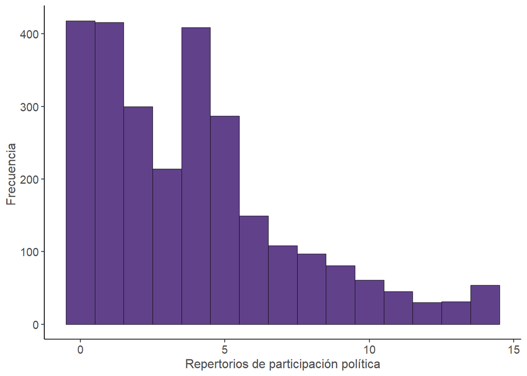

```r
pl <- ggplot(data, aes(x=part_pol_20))
dist<- pl + geom_histogram(binwidth=1, aes(fill=..count..), col='black', fill="#61418A") + theme("clasic") + set_theme(legend.pos  ="bottom", base = theme_classic()) + xlab("Repertorios de participación política") + ylab("Frecuencia ")
dist
```

### Descriptivo 2: frecuencias

```r
data$part_pol_20 %>% table()
```

```
## .
##   0   1   2   3   4   5   6   7   8   9  10  11  12  13  14
## 418 416 300 214 409 287 149 108  97  81  61  45  30  31  54
```

### Descriptivo 3: proporción

```r
round(prop.table(table(data$part_pol_20)),3)
```

```
##
##     0     1     2     3     4     5     6     7     8     9    10    11    12
## 0.155 0.154 0.111 0.079 0.151 0.106 0.055 0.040 0.036 0.030 0.023 0.017 0.011
##    13    14
## 0.011 0.020
```

### Descriptivo 4: estadísticos descriptivos

```r
summary(data$part_pol_20)
```

```
##    Min. 1st Qu.  Median    Mean 3rd Qu.    Max.    NA's
##   0.000   1.000   4.000   3.892   5.000  14.000     441
```

# Ola 2

## Participación política durante la educación superior (para quienes ya no estudian)

**Durante el periodo en que cursó sus estudios de Educación Superior, ¿con qué frecuencia realizó las siguientes actividades (dentro o fuera de la institución)?**

- Firmar una petición, presencialmente o por internet (edsup_09_1)
- Participar en una marcha o manifestación pacífica (edsup_09_2)
- Participar en una marcha o manifestación con disturbios (edsup_09_3)
- Participar en bloqueo de calles o carreteras (edsup_09_8)
- Pintar o rayar paredes con demandas o consignas (edsup_09_9)
- Participar en la toma de un edificio o institución (edsup_09_10)
- Trabajar como voluntario en servicios a la comunidad (edsup_09_11)
- Participar en una marcha con mis amigos (edsup_09_12)
- Participar en una marcha con alguno de mis padres (edsup_09_14)
- Participar en una marcha con otros miembros de mi familia (edsup_09_15)

**Durante el periodo en que cursó sus estudios de Educación Superior, ¿con qué frecuencia realizó las siguientes actividades?**

- Usar internet para buscar información sobre temas sociales y/o políticos (edsup_10_5)
- Postear imágenes o mensajes acerca de temas sociales y/o políticos en internet (edsup_10_6)
- Compartir o comentar en el posteo de otra persona acerca de temas sociales y políticos (edsup_10_7)
- Seguir a personas en redes sociales por su contenido sobre temas sociales y políticos (edsup_10_8)

```r
#### Recodificar variables
# se excluye: + Participar en una marcha con compañeros de carrera (edsup_09_13)

data2$edsup_09_1_rec = ifelse(data2$edsup_09_1==1|data2$edsup_09_1==2,0,1)
data2$edsup_09_2_rec = ifelse(data2$edsup_09_2==1|data2$edsup_09_2==2,0,1)
data2$edsup_09_3_rec = ifelse(data2$edsup_09_3==1|data2$edsup_09_3==2,0,1)
data2$edsup_09_8_rec = ifelse(data2$edsup_09_8==1|data2$edsup_09_8==2,0,1)
data2$edsup_09_9_rec = ifelse(data2$edsup_09_9==1|data2$edsup_09_9==2,0,1)
data2$edsup_09_10_rec = ifelse(data2$edsup_09_10==1|data2$edsup_09_10==2,0,1)
data2$edsup_09_11_rec = ifelse(data2$edsup_09_11==1|data2$edsup_09_11==2,0,1)
data2$edsup_09_12_rec = ifelse(data2$edsup_09_12==1|data2$edsup_09_12==2,0,1)
#data2$edsup_09_13_rec = ifelse(data2$edsup_09_13==1|data2$edsup_09_13==2,0,1)
data2$edsup_09_14_rec = ifelse(data2$edsup_09_14==1|data2$edsup_09_14==2,0,1)
data2$edsup_09_15_rec = ifelse(data2$edsup_09_15==1|data2$edsup_09_15==2,0,1)
data2$edsup_10_5_rec = ifelse(data2$edsup_10_5==1|data2$edsup_10_5==2,0,1)
data2$edsup_10_6_rec = ifelse(data2$edsup_10_6==1|data2$edsup_10_6==2,0,1)
data2$edsup_10_7_rec = ifelse(data2$edsup_10_7==1|data2$edsup_10_7==2,0,1)
data2$edsup_10_8_rec = ifelse(data2$edsup_10_8==1|data2$edsup_10_8==2,0,1)
```

```r
#### Crear variable
data2$part_pol_edsup_egre = as.numeric(data2$edsup_09_1_rec + data2$edsup_09_2_rec + data2$edsup_09_3_rec + data2$edsup_09_8_rec + data2$edsup_09_9_rec + data2$edsup_09_10_rec + data2$edsup_09_11_rec + data2$edsup_09_12_rec + data2$edsup_09_14_rec + data2$edsup_09_15_rec + data2$edsup_10_5_rec + data2$edsup_10_6_rec + data2$edsup_10_7_rec + data2$edsup_10_8_rec)
```

### Descriptivo 1: distribución de la variable

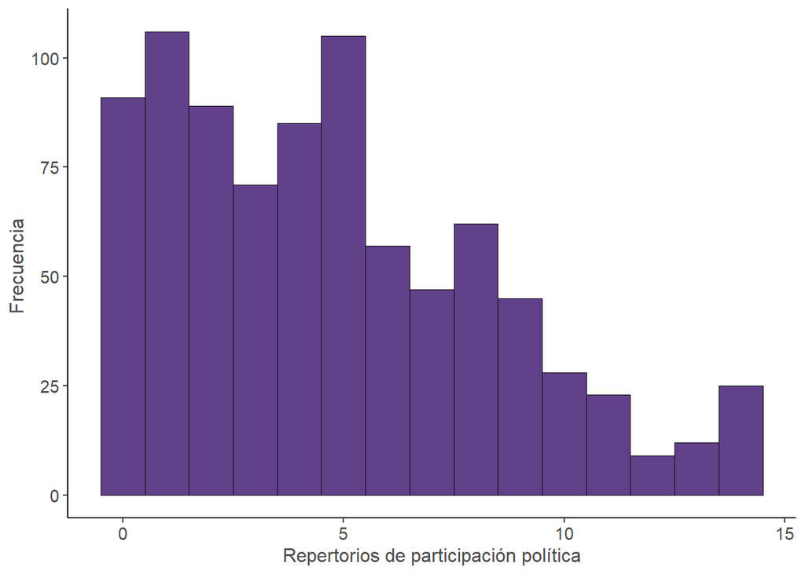

```r
pl <- ggplot(data2, aes(x=part_pol_edsup_egre))
dist<- pl + geom_histogram(binwidth=1, aes(fill=..count..), col='black', fill="#61418A") + theme("clasic") + set_theme(legend.pos  ="bottom", base = theme_classic()) + xlab("Repertorios de participación política") + ylab("Frecuencia ")
dist
```

### Descriptivo 2: frecuencias

```r
data2$part_pol_edsup_egre %>% table()
```

```
## .
##   0   1   2   3   4   5   6   7   8   9  10  11  12  13  14
##  91 106  89  71  85 105  57  47  62  45  28  23   9  12  25
```

### Descriptivo 3: proporción

```r
round(prop.table(table(data2$part_pol_edsup_egre)),3)
```

```
##
##     0     1     2     3     4     5     6     7     8     9    10    11    12
## 0.106 0.124 0.104 0.083 0.099 0.123 0.067 0.055 0.073 0.053 0.033 0.027 0.011
##    13    14
## 0.014 0.029
```

### Descriptivo 4: estadísticos descriptivos

```r
summary(data2$part_pol_edsup_egre)
```

```
##    Min. 1st Qu.  Median    Mean 3rd Qu.    Max.    NA's
##   0.000   2.000   4.000   4.773   7.000  14.000     695
```

## Participación política durante la educación superior (para quienes aún estudian)

**Considerando los últimos meses, el primer semestre de 2021, ¿con qué frecuencia realizó las siguientes actividades?**

- Firmar una petición, presencialmente o por internet (part_act_01_1)
- Participar en una marcha o manifestación pacífica (part_act_01_2)
- Participar en una marcha o manifestación con disturbios (part_act_01_3)
- Participar en bloqueo de calles o carreteras (part_act_01_8)
- Pintar o rayar paredes con demandas o consignas (part_act_01_9)
- Participar en la toma de un edificio o institución (part_act_01_10)
- Trabajar como voluntario en servicios a la comunidad (part_act_01_11)
- Participar en una marcha con mis amigos (part_act_01_12)
- Participar en una marcha con alguno de mis padres (part_act_01_14)
- Participar en una marcha con otros miembros de mi familia (part_act_01_15)

**Considerando los últimos meses, el primer semestre de 2021, ¿con qué frecuencia realizó las siguientes actividades?**

- Usar internet para buscar información sobre temas sociales y/o políticos (part_act_02_5)
- Postear imágenes o mensajes acerca de temas sociales y/o políticos en internet (part_act_02_6)
- Compartir o comentar en el posteo de otra persona acerca de temas sociales y políticos (part_act_02_7)
- Seguir a personas en redes sociales por su contenido sobre temas sociales y políticos (part_act_02_8)

```r
#### Crear variable
data_est_act$part_pol_edsup_act = as.numeric(data_est_act$part_act_01_1_rec + data_est_act$part_act_01_2_rec + data_est_act$part_act_01_3_rec + data_est_act$part_act_01_8_rec + data_est_act$part_act_01_9_rec + data_est_act$part_act_01_10_rec + data_est_act$part_act_01_11_rec + data_est_act$part_act_01_12_rec + data_est_act$part_act_01_14_rec + data_est_act$part_act_01_15_rec + data_est_act$part_act_02_5_rec + data_est_act$part_act_02_6_rec + data_est_act$part_act_02_7_rec + data_est_act$part_act_02_8_rec)
```

### Descriptivo 1: distribución de la variable

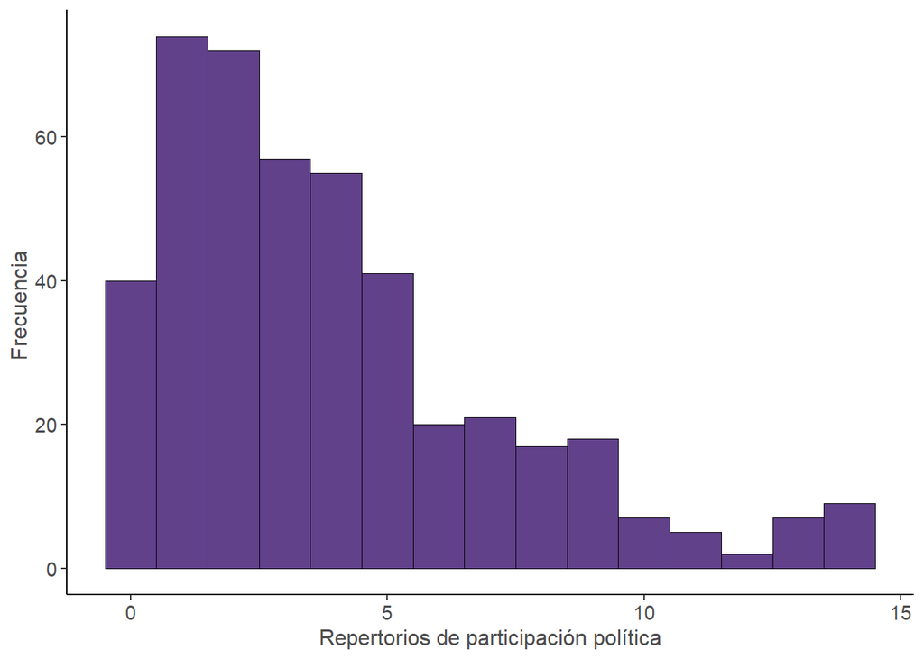

```r
pl <- ggplot(data_est_act, aes(x=part_pol_edsup_act))
dist<- pl + geom_histogram(binwidth=1, aes(fill=..count..), col='black', fill="#61418A") + theme("clasic") + set_theme(legend.pos  ="bottom", base = theme_classic()) + xlab("Repertorios de participación política") + ylab("Frecuencia ")
dist
```

### Descriptivo 2: frecuencias

```r
data_est_act$part_pol_edsup_act %>% table()
```

```
## .
##  0  1  2  3  4  5  6  7  8  9 10 11 12 13 14
## 40 74 72 57 55 41 20 21 17 18  7  5  2  7  9
```

### Descriptivo 3: proporción

```r
round(prop.table(table(data_est_act$part_pol_edsup_act)),3)
```

```
##
##     0     1     2     3     4     5     6     7     8     9    10    11    12
## 0.090 0.166 0.162 0.128 0.124 0.092 0.045 0.047 0.038 0.040 0.016 0.011 0.004
##    13    14
## 0.016 0.020
```

### Descriptivo 4: estadísticos descriptivos

```r
summary(data_est_act$part_pol_edsup_act)
```

```
##    Min. 1st Qu.  Median    Mean 3rd Qu.    Max.    NA's
##   0.000   1.000   3.000   3.921   5.000  14.000      19
```

## Participación política durante los últimos meses

**Considerando los últimos meses, el primer semestre de 2021, ¿con qué frecuencia realizó las siguientes actividades?**

- Firmar una petición, presencialmente o por internet (part_act_01_1)
- Participar en una marcha o manifestación pacífica (part_act_01_2)
- Participar en una marcha o manifestación con disturbios (part_act_01_3)
- Participar en bloqueo de calles o carreteras (part_act_01_8)
- Pintar o rayar paredes con demandas o consignas (part_act_01_9)
- Participar en la toma de un edificio o institución (part_act_01_10)
- Trabajar como voluntario en servicios a la comunidad (part_act_01_11)
- Participar en una marcha con mis amigos (part_act_01_12)
- Participar en una marcha con alguno de mis padres (part_act_01_14)
- Participar en una marcha con otros miembros de mi familia (part_act_01_15)

**Considerando los últimos meses, el primer semestre de 2021, ¿con qué frecuencia realizó las siguientes actividades?**

- Usar internet para buscar información sobre temas sociales y/o políticos (part_act_02_5)
- Postear imágenes o mensajes acerca de temas sociales y/o políticos en internet (part_act_02_6)
- Compartir o comentar en el posteo de otra persona acerca de temas sociales y políticos (part_act_02_7)
- Seguir a personas en redes sociales por su contenido sobre temas sociales y políticos (part_act_02_8)

```r
#### Crear variable
data2$part_pol_21_1s = as.numeric(data2$part_act_01_1_rec + data2$part_act_01_2_rec + data2$part_act_01_3_rec + data2$part_act_01_8_rec + data2$part_act_01_9_rec + data2$part_act_01_10_rec + data2$part_act_01_11_rec + data2$part_act_01_12_rec + data2$part_act_01_14_rec + data2$part_act_01_15_rec + data2$part_act_02_5_rec + data2$part_act_02_6_rec + data2$part_act_02_7_rec + data2$part_act_02_8_rec)
```

### Descriptivo 1: distribución de la variable

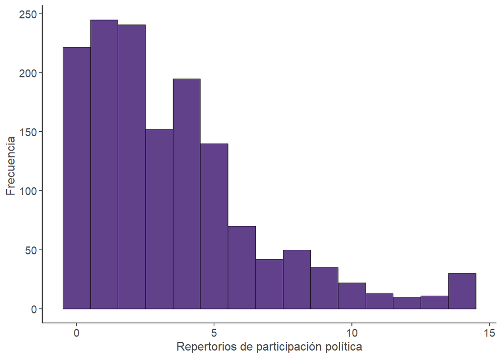

```r
pl <- ggplot(data2, aes(x=part_pol_21_1s))
dist<- pl + geom_histogram(binwidth=1, aes(fill=..count..), col='black', fill="#61418A") + theme("clasic") + set_theme(legend.pos  ="bottom", base = theme_classic()) + xlab("Repertorios de participación política") + ylab("Frecuencia ")
dist
```

### Descriptivo 2: frecuencias

```r
data2$part_pol_21_1s %>% table()
```

```
## .
##   0   1   2   3   4   5   6   7   8   9  10  11  12  13  14
## 222 245 241 152 195 140  70  42  50  35  22  13  10  11  30
```

### Descriptivo 3: proporción

```r
round(prop.table(table(data2$part_pol_21_1s)),3)
```

```
##
##     0     1     2     3     4     5     6     7     8     9    10    11    12
## 0.150 0.166 0.163 0.103 0.132 0.095 0.047 0.028 0.034 0.024 0.015 0.009 0.007
##    13    14
## 0.007 0.020
```

### Descriptivo 4: estadísticos descriptivos

```r
summary(data2$part_pol_21_1s)
```

```
##    Min. 1st Qu.  Median    Mean 3rd Qu.    Max.    NA's
##   0.000   1.000   3.000   3.476   5.000  14.000      72
```

# Ola 3

## Participación política durante el segundo semestre de 2021

**Considerando los últimos meses, el segundo semestre de 2021 (entre agosto y diciembre), ¿con qué frecuencia realizó las siguientes actividades?**

- Firmar una petición, presencialmente o por internet (part_act_01_1)
- Participar en una marcha o manifestación pacífica (part_act_01_2)
- Participar en una marcha o manifestación con disturbios (part_act_01_3)
- Participar en bloqueo de calles o carreteras (part_act_01_8)
- Pintar o rayar paredes con demandas o consignas (part_act_01_9)
- Participar en la toma de un edificio o institución (part_act_01_10)
- Trabajar como voluntario en servicios a la comunidad (part_act_01_11)
- Participar en una marcha con mis amigos (part_act_01_12)
- Participar en una marcha con alguno de mis padres (part_act_01_14)
- Participar en una marcha con otros miembros de mi familia (part_act_01_15)

**Considerando los últimos meses, el segundo semestre de 2021 (entre agosto y diciembre), ¿con qué frecuencia realizó las siguientes actividades?**

- Usar internet para buscar información sobre temas sociales y/o políticos (part_act_02_5)
- Postear imágenes o mensajes acerca de temas sociales y/o políticos en internet (part_act_02_6)
- Compartir o comentar en el posteo de otra persona acerca de temas sociales y políticos (part_act_02_7)
- Seguir a personas en redes sociales por su contenido sobre temas sociales y políticos (part_act_02_8)

```r
#### Crear variable
data3$part_pol_21_2s = as.numeric(data3$part_act_01_1_rec + data3$part_act_01_2_rec + data3$part_act_01_3_rec + data3$part_act_01_8_rec + data3$part_act_01_9_rec + data3$part_act_01_10_rec + data3$part_act_01_11_rec + data3$part_act_01_12_rec + data3$part_act_01_14_rec + data3$part_act_01_15_rec + data3$part_act_02_5_rec + data3$part_act_02_6_rec + data3$part_act_02_7_rec + data3$part_act_02_8_rec)
```

### Descriptivo 1: distribución de la variable

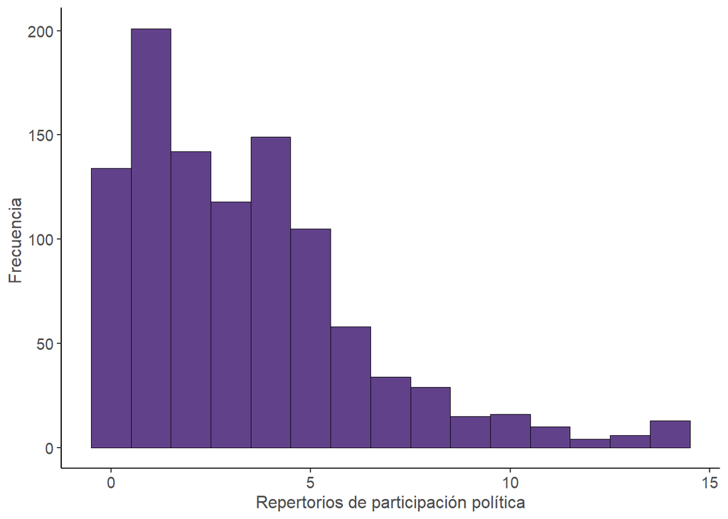

```r
pl <- ggplot(data3, aes(x=part_pol_21_2s))
dist<- pl + geom_histogram(binwidth=1, aes(fill=..count..), col='black', fill="#61418A") + theme("clasic") + set_theme(legend.pos  ="bottom", base = theme_classic()) + xlab("Repertorios de participación política") + ylab("Frecuencia ")
dist
```

### Descriptivo 2: frecuencias

```r
data3$part_pol_21_2s %>% table()
```

```
## .
##   0   1   2   3   4   5   6   7   8   9  10  11  12  13  14
## 134 201 142 118 149 105  58  34  29  15  16  10   4   6  13
```

### Descriptivo 3: proporción

```r
round(prop.table(table(data3$part_pol_21_2s)),3)
```

```
##
##     0     1     2     3     4     5     6     7     8     9    10    11    12
## 0.130 0.194 0.137 0.114 0.144 0.102 0.056 0.033 0.028 0.015 0.015 0.010 0.004
##    13    14
## 0.006 0.013
```

### Descriptivo 4: estadísticos descriptivos

```r
summary(data3$part_pol_21_2s)
```

```
##    Min. 1st Qu.  Median    Mean 3rd Qu.    Max.    NA's
##   0.000   1.000   3.000   3.376   5.000  14.000      36
```

## Participación política durante el segundo semestre de 2021 (para quienes aún estudian)

**Considerando los últimos meses, el segundo semestre de 2021 (entre agosto y diciembre), ¿con qué frecuencia realizó las siguientes actividades?**

- Firmar una petición, presencialmente o por internet (part_act_01_1)
- Participar en una marcha o manifestación pacífica (part_act_01_2)
- Participar en una marcha o manifestación con disturbios (part_act_01_3)
- Participar en bloqueo de calles o carreteras (part_act_01_8)
- Pintar o rayar paredes con demandas o consignas (part_act_01_9)
- Participar en la toma de un edificio o institución (part_act_01_10)
- Trabajar como voluntario en servicios a la comunidad (part_act_01_11)
- Participar en una marcha con mis amigos (part_act_01_12)
- Participar en una marcha con alguno de mis padres (part_act_01_14)
- Participar en una marcha con otros miembros de mi familia (part_act_01_15)

**Considerando los últimos meses, el segundo semestre de 2021 (entre agosto y diciembre), ¿con qué frecuencia realizó las siguientes actividades?**

- Usar internet para buscar información sobre temas sociales y/o políticos (part_act_02_5)
- Postear imágenes o mensajes acerca de temas sociales y/o políticos en internet (part_act_02_6)
- Compartir o comentar en el posteo de otra persona acerca de temas sociales y políticos (part_act_02_7)
- Seguir a personas en redes sociales por su contenido sobre temas sociales y políticos (part_act_02_8)

```r
#### Crear variable
data_est_act3$part_pol_21_2s_est_act = as.numeric(data_est_act3$part_act_01_1_rec + data_est_act3$part_act_01_2_rec + data_est_act3$part_act_01_3_rec + data_est_act3$part_act_01_8_rec + data_est_act3$part_act_01_9_rec + data_est_act3$part_act_01_10_rec + data_est_act3$part_act_01_11_rec + data_est_act3$part_act_01_12_rec + data_est_act3$part_act_01_14_rec + data_est_act3$part_act_01_15_rec + data_est_act3$part_act_02_5_rec + data_est_act3$part_act_02_6_rec + data_est_act3$part_act_02_7_rec + data_est_act3$part_act_02_8_rec)
```

### Descriptivo 1: distribución de la variable

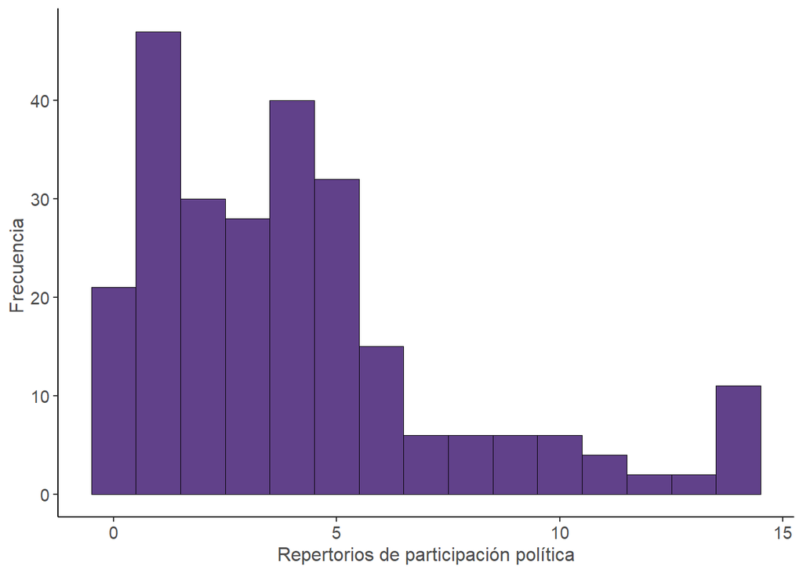

```r
pl <- ggplot(data_est_act3, aes(x=part_pol_21_2s_est_act))
dist<- pl + geom_histogram(binwidth=1, aes(fill=..count..), col='black', fill="#61418A") + theme("clasic") + set_theme(legend.pos  ="bottom", base = theme_classic()) + xlab("Repertorios de participación política") + ylab("Frecuencia ")
dist
```

### Descriptivo 2: frecuencias

```r
data_est_act3$part_pol_21_2s_est_act %>% table()
```

```
## .
##  0  1  2  3  4  5  6  7  8  9 10 11 12 13 14
## 21 47 30 28 40 32 15  6  6  6  6  4  2  2 11
```

### Descriptivo 3: proporción

```r
round(prop.table(table(data_est_act3$part_pol_21_2s_est_act)),3)
```

```
##
##     0     1     2     3     4     5     6     7     8     9    10    11    12
## 0.082 0.184 0.117 0.109 0.156 0.125 0.059 0.023 0.023 0.023 0.023 0.016 0.008
##    13    14
## 0.008 0.043
```

### Descriptivo 4: estadísticos descriptivos

```r
summary(data_est_act3$part_pol_21_2s_est_act)
```

```
##    Min. 1st Qu.  Median    Mean 3rd Qu.    Max.    NA's
##   0.000   1.000   4.000   4.113   5.000  14.000      14
```